# Session 6: Homework 3 — ANSWER KEY

**Instructor solution.** Every task is worked in full, with the code *and* a short written interpretation (the "so-what"). Prompts from the assignment are kept as headers so this maps one-to-one onto the student notebook.

Three datasets are used: **YRBSS** (CDC youth health survey), **movies** (IMDB), and **omega** (executive pay). Numbers in the commentary are produced by the cells below and will reproduce on re-run.

> *Teaching threads to emphasise:* (1) a hypothesis test, a confidence interval, and a regression are three views of the **same** comparison; (2) **overlapping CIs do not imply a non-significant difference**; (3) "controlling for" a confounder (experience) can dissolve an apparent effect (gender); (4) always ask whether a significant result is **practically** meaningful and whether it is **causal**.

## Setup

```python
# Libraries
import pandas as pd
import numpy as np
import matplotlib.pyplot as plt
import seaborn as sns
from scipy import stats
from scipy.stats import ttest_ind
from scipy.stats import t                      # t-distribution for CIs
from statsmodels.stats.proportion import proportion_confint
import statsmodels.formula.api as smf
import warnings
warnings.filterwarnings('ignore')

plt.style.use('default')
sns.set_palette('husl')
plt.rcParams['font.size'] = 12
plt.rcParams['font.family'] = 'sans-serif'

# --- small helper so this notebook runs whether data is in ../data or ./data ---
import os
def data_path(name):
    for base in ['../data/', 'data/', './']:
        if os.path.exists(os.path.join(base, name)):
            return os.path.join(base, name)
    return '../data/' + name
```

# Youth Risk Behavior Surveillance

Data from the CDC YRBSS survey — a random sample of US high-schoolers (grades 9–12). We work with a selection of health-behaviour variables.

```python
yrbss = pd.read_csv(data_path('yrbss.csv'))
print(yrbss.info())
```

```
<class 'pandas.DataFrame'>
RangeIndex: 13583 entries, 0 to 13582
Data columns (total 13 columns):
 #   Column                    Non-Null Count  Dtype
---  ------                    --------------  -----
 0   age                       13506 non-null  float64
 1   gender                    13571 non-null  str
 2   grade                     13504 non-null  str
 3   hispanic                  13352 non-null  str
 4   race                      10778 non-null  str
 5   height                    12579 non-null  float64
 6   weight                    12579 non-null  float64
 7   helmet_12m                13272 non-null  str
 8   text_while_driving_30d    12665 non-null  str
 9   physically_active_7d      13310 non-null  float64
 10  hours_tv_per_school_day   13245 non-null  str
 11  strength_training_7d      12407 non-null  float64
 12  school_night_hours_sleep  12335 non-null  str
dtypes: float64(5), str(8)
memory usage: 1.3 MB
None
```

## Exploratory Data Analysis

- Analyze the `weight` of participants in kilograms. Quick summary stats with `describe()`
- How many missing weights?
- What does a quick histogram of weights look like?

```
count    12579.00
mean        67.91
std         16.90
min         29.94
25%         56.25
50%         64.41
75%         76.20
max        180.99
Name: weight, dtype: float64

Missing weights: 1,004 of 13,583 (7.4%)
```

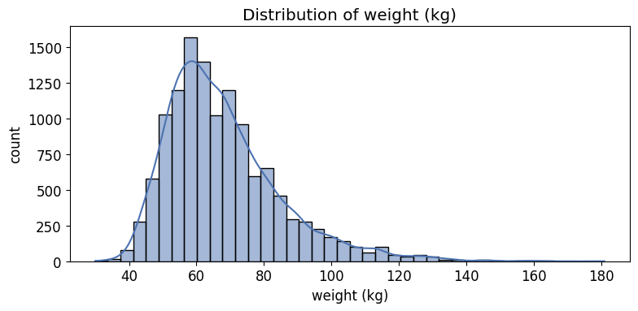

```python
# Summary statistics for weight (kg)
print(yrbss['weight'].describe().round(2))

# Missing weights
n_missing = yrbss['weight'].isna().sum()
print(f"\nMissing weights: {n_missing:,} of {len(yrbss):,} "
      f"({n_missing/len(yrbss):.1%})")

# Histogram
plt.figure(figsize=(8, 4))
sns.histplot(yrbss['weight'].dropna(), bins=40, kde=True, color='#4C72B0')
plt.title('Distribution of weight (kg)')
plt.xlabel('weight (kg)'); plt.ylabel('count')
plt.tight_layout(); plt.show()
```

> **✅ Answer.** Weight ranges from about **30 kg to 181 kg**, with a mean of **67.9 kg** and a median of **64.4 kg**. The mean sitting above the median, plus the long right tail in the histogram, tells us the distribution is **right-skewed** — a minority of heavier students pull the average up. **1,004 students (7.4%)** did not report a weight; those rows drop out of any weight-based analysis, so all weight results below are conditional on *"students who reported a weight."*

## Physical Activity Variable

- Create a new variable `physical_3plus`, by looking whether `physically_active_7d` is greater than 3.
- Calculate number and % of those who are and are not active for more than 3 days.

```python
# 'yes' if physically active on more than 3 of the last 7 days, else 'no'
yrbss['physical_3plus'] = np.where(yrbss['physically_active_7d'] > 3, 'yes', 'no')

counts = yrbss['physical_3plus'].value_counts()
props  = yrbss['physical_3plus'].value_counts(normalize=True)
summary = pd.DataFrame({'n': counts, 'percent': (props*100).round(1)})
print(summary)
```

```
                   n  percent
physical_3plus
yes             7455     54.9
no              6128     45.1
```

> **✅ Answer.** About **54.9% (7,455)** are active on 3+ days and **45.1% (6,128)** are not.

> **Subtlety worth flagging to students.** `np.where(... > 3, 'yes', 'no')` treats a **missing** activity value as *not* `> 3`, so the ~273 students with a missing `physically_active_7d` are silently bundled into `'no'`. That's the convention this exercise uses (and it's what the proportion cell below assumes), but a more careful build would exclude missings first: `np.where(active.isna(), np.nan, active > 3)`. Excluding them, the `'no'` group is 5,855 rather than 6,128 — a good discussion point about how a one-line recode can quietly make a modelling decision for you.

## 95% Confidence Interval for Proportion

- Calculate a 95% CI for those NOT active 3+ days. Do you get the same answer as `proportion_confint()`?

```python
count = (yrbss['physical_3plus'] == 'no').sum()
nobs  = len(yrbss)
phat  = count / nobs

# --- by hand: p_hat +/- z * sqrt( p_hat (1-p_hat) / n ) ---
z  = stats.norm.ppf(0.975)                 # 1.96
se = np.sqrt(phat * (1 - phat) / nobs)
lo, hi = phat - z*se, phat + z*se
print(f"p_hat (not active 3+) = {phat:.4f}")
print(f"by hand 95% CI       : [{lo:.4f}, {hi:.4f}]")

# --- statsmodels ---
ci_low, ci_upp = proportion_confint(count, nobs, alpha=0.05, method='normal')
print(f"proportion_confint   : [{ci_low:.4f}, {ci_upp:.4f}]")
```

```
p_hat (not active 3+) = 0.4512
by hand 95% CI       : [0.4428, 0.4595]
proportion_confint   : [0.4428, 0.4595]
```

> **✅ Answer.** By hand we get **[0.4428, 0.4595]**, which matches `proportion_confint(..., method='normal')` to four decimals. They agree because `method='normal'` *is* the textbook normal (Wald) approximation: $\hat p \pm z_{0.975}\sqrt{\hat p(1-\hat p)/n}$. With n ≈ 13,600 the interval is very tight (±0.8 percentage points): we can be quite confident that just under **46%** of students are not active on 3+ days. (Aside: `proportion_confint` also offers `method='wilson'`, which is more accurate for proportions near 0 or 1 — not an issue here since $\hat p$ is near 0.5.)

## Boxplot: physical_3plus vs. weight

Create a boxplot of weight (y-axis) by physical_3plus (x-axis) using seaborn. What do you observe?

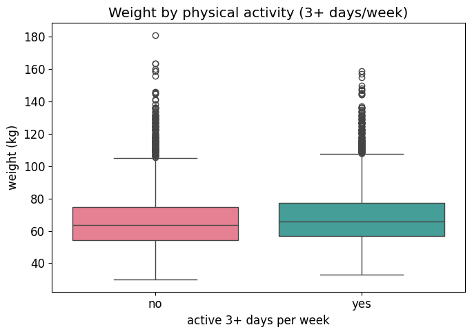

```python
plt.figure(figsize=(7, 5))
sns.boxplot(data=yrbss, x='physical_3plus', y='weight',
            order=['no', 'yes'], palette='husl')
plt.title('Weight by physical activity (3+ days/week)')
plt.xlabel('active 3+ days per week'); plt.ylabel('weight (kg)')
plt.tight_layout(); plt.show()
```

> **✅ Answer.** The two boxes look **almost identical** — medians, boxes and the spread of outliers are very close, with maybe a *hair* higher weight for the active group. Eyeballing a boxplot, you would guess there is little or no difference. That sets up the useful surprise in the formal test below: with a huge sample, even the tiny gap the eye can barely see turns out to be flagged as statistically significant.

## Confidence Interval for Means

Calculate a 95% CI for the mean weight of participants who are physically active 3+ days a week and those who are not. Do you observe a difference?

```python
weight_ci = (
    yrbss.dropna(subset=['weight'])
    .groupby('physical_3plus')['weight']
    .agg(['mean', 'std', 'count'])
    .assign(
        se       = lambda x: x['std'] / np.sqrt(x['count']),
        t_crit   = lambda x: stats.t.ppf(0.975, x['count'] - 1),
        moe      = lambda x: x['t_crit'] * x['se'],
        ci_low   = lambda x: x['mean'] - x['moe'],
        ci_high  = lambda x: x['mean'] + x['moe'],
    )
    .round(2)
)
print(weight_ci[['mean', 'std', 'count', 'se', 'ci_low', 'ci_high']])
```

```
                 mean    std  count    se  ci_low  ci_high
physical_3plus
no              67.19  17.62   5605  0.24   66.73    67.65
yes             68.48  16.27   6974  0.19   68.10    68.87
```

> **✅ Answer.** Active students: mean **68.48 kg**, 95% CI **[68.10, 68.87]**. Not-active: mean **67.19 kg**, 95% CI **[66.73, 67.65]**. The two intervals **do not overlap** (68.10 > 67.65), which signals a real — if small — difference: the active group is on average about **1.3 kg heavier**. Note the *direction* is the opposite of the naive expectation that exercise means lower weight (more on that after the test).

## Hypothesis Test: t-test

Is the difference in mean weight between those who exercise 3+ days and those who don't statistically significant? State the null and alternative hypotheses and use a t-test. We also provide the regression version to check they agree.

```python
# H0: mu_yes - mu_no = 0   (no difference in mean weight)
# H1: mu_yes - mu_no != 0   (two-sided)

wy = yrbss.loc[yrbss['physical_3plus'] == 'yes', 'weight'].dropna()
wn = yrbss.loc[yrbss['physical_3plus'] == 'no',  'weight'].dropna()

t_stat, p_value = ttest_ind(wy, wn, equal_var=False)   # Welch
print("Welch two-sample t-test (weight: active vs not)")
print(f"  mean difference : {wy.mean() - wn.mean():+.3f} kg")
print(f"  t-statistic     : {t_stat:.3f}")
print(f"  p-value         : {p_value:.2e}")
```

```
Welch two-sample t-test (weight: active vs not)
  mean difference : +1.296 kg
  t-statistic     : 4.242
  p-value         : 2.23e-05
```

```python
# --- Same test as a regression: weight ~ C(physical_3plus) ---
model = smf.ols('weight ~ C(physical_3plus)', data=yrbss).fit()
print(model.summary2().tables[1].round(4))
```

```
                            Coef.  Std.Err.         t  P>|t|   [0.025  0.975]
Intercept                 67.1878    0.2256  297.8766    0.0  66.7457   67.63
C(physical_3plus)[T.yes]   1.2962    0.3029    4.2791    0.0   0.7025    1.89
```

> **✅ Answer.** **Hypotheses.** $H_0:\mu_{\text{yes}}=\mu_{\text{no}}$ versus $H_1:\mu_{\text{yes}}\neq\mu_{\text{no}}$.

> **Result.** $t = 4.24$, $p \approx 2\times10^{-5}$ — we **reject $H_0$**. The mean weights differ, with active students about **1.30 kg heavier**.

> **The regression is the same test.** `C(physical_3plus)[T.yes]` has coefficient **+1.30** (baseline = `no`) with $t = 4.28$, $p \approx 2\times10^{-5}$ — the slope *is* the difference in means, and its t-statistic matches the t-test (tiny differences come from Welch vs the equal-variance OLS standard error).

> **So-what — read this carefully.** The result is **statistically** significant but the effect is **small** (1.3 kg on weights that range over 150 kg) and it runs *opposite* to the "exercise → lower weight" intuition. Two honest takeaways: (1) with n ≈ 12,600 almost any non-zero gap becomes significant, so report the **effect size**, not just the p-value; (2) this is **observational** — heavier teens may do more strength training (muscle weighs more), or activity and weight may be linked through many other factors. Significance here is **not** evidence that exercising makes you heavier.

# IMDB ratings: Differences between directors

- From the movies dataset, get movies directed by Spielberg and Burton
- Produce two confidence intervals for the average rating of these two directors
- Do the confidence intervals overlap?
- Run a t-test

```python
movies = pd.read_csv(data_path('movies.csv'))

two_dir = movies[movies['director'].isin(['Steven Spielberg', 'Tim Burton'])]

dir_ci = (
    two_dir.groupby('director')['rating']
    .agg(['mean', 'std', 'count'])
    .assign(
        se      = lambda x: x['std'] / np.sqrt(x['count']),
        t_crit  = lambda x: stats.t.ppf(0.975, x['count'] - 1),
        moe     = lambda x: x['t_crit'] * x['se'],
        ci_low  = lambda x: x['mean'] - x['moe'],
        ci_high = lambda x: x['mean'] + x['moe'],
    )
    .round(3)
)
print(dir_ci[['mean', 'count', 'se', 'ci_low', 'ci_high']])
```

```
                   mean  count     se  ci_low  ci_high
director
Steven Spielberg  7.574     23  0.145   7.273    7.874
Tim Burton        6.931     16  0.187   6.532    7.330
```

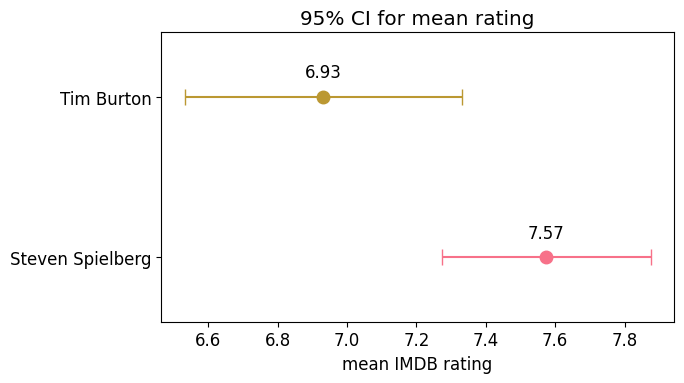

```
Spielberg - Burton difference: +0.643
Welch t = 2.714,  p = 0.0108
```

```python
# Visualise the two CIs
fig, ax = plt.subplots(figsize=(7, 4))
for i, (name, row) in enumerate(dir_ci.iterrows()):
    ax.errorbar(row['mean'], i,
                xerr=row['moe'], fmt='o', capsize=6, markersize=9)
    ax.text(row['mean'], i + 0.12, f"{row['mean']:.2f}", ha='center')
ax.set_yticks([0, 1]); ax.set_yticklabels(dir_ci.index)
ax.set_xlabel('mean IMDB rating'); ax.set_title('95% CI for mean rating')
ax.margins(y=0.4); plt.tight_layout(); plt.show()

# t-test
sp = two_dir.loc[two_dir['director'] == 'Steven Spielberg', 'rating']
bu = two_dir.loc[two_dir['director'] == 'Tim Burton', 'rating']
t_stat, p_value = ttest_ind(sp, bu, equal_var=False)
print(f"Spielberg - Burton difference: {sp.mean() - bu.mean():+.3f}")
print(f"Welch t = {t_stat:.3f},  p = {p_value:.4f}")
```

> **✅ Answer.** Spielberg averages **7.57** (95% CI **[7.27, 7.87]**, n = 23); Burton averages **6.93** (95% CI **[6.53, 7.33]**, n = 16).

> **Do the CIs overlap?** *Yes — just barely* (Burton's upper 7.33 sits above Spielberg's lower 7.27).

> **Does the t-test agree?** The Welch test gives $t = 2.71$, $p = 0.011$ — a **significant** difference of about **0.64** rating points.

> **This is the key teaching point.** The two 95% CIs overlap, yet the difference *is* significant at 5%. The "overlapping CIs ⇒ no significant difference" rule of thumb is **wrong** (it is too conservative). The correct object is the CI for the *difference in means*, which here excludes zero. When two individual CIs overlap a little, you cannot conclude anything — you must test the difference directly.

# Omega Group plc — Pay Discrimination

A board member claims women are underpaid: in a sample of 50 executives (24 men, 26 women) the average male salary is about £8,400 higher. We test whether the gap is real and whether it survives controlling for **experience**. We use four lenses — CIs, a t-test, correlation, and regression — and confirm they agree.

```python
omega = pd.read_csv(data_path('omega.csv'))
print(omega.groupby('gender')['salary'].describe().T.round(2))
```

```
gender    female      male
count      26.00     24.00
mean    64542.84  73239.13
std      7567.26   7462.60
min     47032.57  54768.19
25%     60337.83  68331.31
50%     64618.21  74674.52
75%     70033.14  78568.11
max     78800.18  84576.11
```

### Distribution of salary by gender

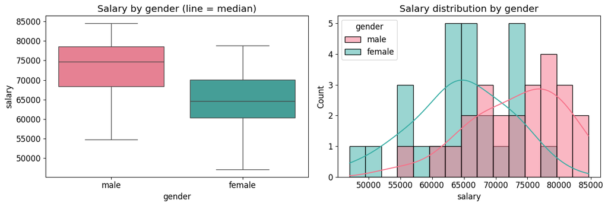

```python
fig, ax = plt.subplots(1, 2, figsize=(13, 4.5))
sns.boxplot(data=omega, x='gender', y='salary', ax=ax[0], palette='husl')
ax[0].set_title('Salary by gender (line = median)')
sns.histplot(data=omega, x='salary', hue='gender', bins=15,
             kde=True, ax=ax[1], palette='husl')
ax[1].set_title('Salary distribution by gender')
plt.tight_layout(); plt.show()
```

> **✅ Answer.** Male salaries sit clearly higher than female salaries across the whole distribution (both the boxes and the histograms are shifted right for men). Spreads look similar. So there is certainly a **raw** gap to explain — the question is *why*.

### 95% (and 99%) confidence intervals "by hand"

Add standard error, t-critical, and CI endpoints to the summary table.

```python
def mean_ci_table(df, group, value, conf=0.95):
    a = 1 - conf
    return (
        df.groupby(group)[value]
        .agg(['mean', 'std', 'count'])
        .assign(
            se      = lambda x: x['std'] / np.sqrt(x['count']),
            t_crit  = lambda x: stats.t.ppf(1 - a/2, x['count'] - 1),
            moe     = lambda x: x['t_crit'] * x['se'],
            ci_low  = lambda x: x['mean'] - x['moe'],
            ci_high = lambda x: x['mean'] + x['moe'],
        ).round(2)
    )

print("95% CIs\n", mean_ci_table(omega, 'gender', 'salary', 0.95)
      [['mean', 'se', 't_crit', 'ci_low', 'ci_high']], "\n")
print("99% CIs\n", mean_ci_table(omega, 'gender', 'salary', 0.99)
      [['mean', 'se', 't_crit', 'ci_low', 'ci_high']])
```

```
95% CIs
             mean       se  t_crit    ci_low   ci_high
gender
female  64542.84  1484.06    2.06  61486.35  67599.32
male    73239.13  1523.30    2.07  70087.95  76390.31

99% CIs
             mean       se  t_crit    ci_low   ci_high
gender
female  64542.84  1484.06    2.79  60406.11  68679.57
male    73239.13  1523.30    2.81  68962.72  77515.53
```

> **✅ Answer.** 95% CIs: women **[61,486, 67,599]**, men **[70,088, 76,390]**. They are far from overlapping, so the gender difference in mean salary is clearly significant — the same verdict the t-test and regression give below. (The 99% intervals are wider but still do not overlap.)

### Hypothesis test — is the salary gap significant?

```python
female_salary = omega.loc[omega['gender'] == 'female', 'salary']
male_salary   = omega.loc[omega['gender'] == 'male',   'salary']

t_stat, p_value = ttest_ind(female_salary, male_salary, equal_var=False)
print(f"female - male difference : {female_salary.mean() - male_salary.mean():,.2f}")
print(f"t-statistic : {t_stat:.3f}")
print(f"p-value     : {p_value:.6f}")
```

```
female - male difference : -8,696.29
t-statistic : -4.089
p-value     : 0.000165
```

> **✅ Answer.** $H_0$: equal mean salaries. The difference is about **−£8,696** (women earn less), $t = -4.09$, $p = 0.00017$ — we **reject $H_0$**. There is a significant raw pay gap. (The sign is just female−male; magnitude matches the board's "£8,400" claim.)

### Correlation check

```python
print("corr(salary, experience), all:",
      round(omega['salary'].corr(omega['experience']), 3))
for g in ['female', 'male']:
    s = omega[omega['gender'] == g]
    print(f"  {g}: {s['salary'].corr(s['experience']):.3f}")
```

```
corr(salary, experience), all: 0.803
  female: 0.812
  male: 0.661
```

> **✅ Answer.** Salary and experience are strongly correlated (**r ≈ 0.80** overall). That is the first hint that **experience**, not gender, may be doing the real work — especially once we recall the men in this sample average ~21 years of experience versus ~7 for the women.

### Regression 1 — salary on gender

What is the estimated slope and its standard error? Is it similar to something you have already seen?

```python
model1 = smf.ols('salary ~ C(gender)', data=omega).fit()
print(model1.summary2().tables[1].round(4))
```

```
                        Coef.   Std.Err.        t   P>|t|      [0.025  \
Intercept          64542.8362  1474.2627  43.7797  0.0000  61578.6323
C(gender)[T.male]   8696.2901  2127.9149   4.0868  0.0002   4417.8304

                       0.975]
Intercept          67507.0400
C(gender)[T.male]  12974.7498
```

> **✅ Answer.** The `C(gender)[T.male]` slope is **+8,696** with SE **2,127.9**, $t = 4.09$, $p = 0.0002$. This is **exactly the t-test again**: the slope equals the male−female mean difference, and its t/p match the earlier test. Confidence interval, t-test, and regression are three views of one comparison. R² ≈ 0.26, so gender alone "explains" about a quarter of salary variation — but we have not yet asked *why*.

> *(Note: the student file called `model1.summary().tables()` — that errors because `.tables` is a list, not a function. Use `model1.summary()` to print everything, or `model1.summary2().tables[1]` to grab just the coefficient table, as above.)*

# Adding experience

The men average ~21 years of experience, the women ~7. Redo the analysis **controlling for experience**: plot experience by gender, then add experience to the regression.

```
         mean  count  ci_low  ci_high
gender
female   7.38     26    3.95    10.82
male    21.12     24   16.52    25.73
```

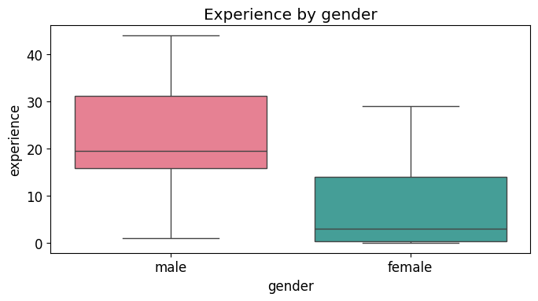

```python
# Experience differs sharply by gender
print(mean_ci_table(omega, 'gender', 'experience', 0.95)
      [['mean', 'count', 'ci_low', 'ci_high']])

plt.figure(figsize=(7, 4))
sns.boxplot(data=omega, x='gender', y='experience', palette='husl')
plt.title('Experience by gender'); plt.tight_layout(); plt.show()
```

```python
model3 = smf.ols('salary ~ C(gender) + experience', data=omega).fit()
print(model3.summary2().tables[1].round(4))
```

```
                        Coef.   Std.Err.        t   P>|t|      [0.025  \
Intercept          60414.1324  1176.2973  51.3596  0.0000  58047.7275
C(gender)[T.male]   1014.1056  1826.3901   0.5553  0.5814  -2660.1173
experience           559.0953    77.6236   7.2026  0.0000    402.9367

                       0.975]
Intercept          62780.5372
C(gender)[T.male]   4688.3285
experience           715.2539
```

> **✅ Answer — the crux of the case.** Once experience is in the model, the **gender coefficient collapses from +8,696 to +1,014** and becomes **insignificant** ($p = 0.58$; CI −2,660 to +4,688). Meanwhile **experience** is highly significant at **+£559 per year** ($p < 0.001$), and R² jumps from 0.26 to **0.65**.

> Interpretation: the raw pay gap is largely a **confounded** comparison — men in this sample are far more experienced, and experience pays. Holding experience constant, we can *no longer detect* a gender difference. The £559 is the average extra salary per additional year of experience, earned by **everyone** in the model (it is the common slope for both genders). This does **not** prove there is no discrimination — it shows this dataset gives no *statistical* evidence of a gender gap once experience is accounted for, and it raises the deeper question of *why* the women have less experience.

# Does experience pay off differently by gender? (interaction)

`salary ~ C(gender) * experience` lets the two genders have different **slopes**, not just different intercepts.

```python
model4 = smf.ols('salary ~ C(gender) * experience', data=omega).fit()
print(model4.summary2().tables[1].round(4))
```

```
                                   Coef.   Std.Err.        t   P>|t|  \
Intercept                     59213.6343  1342.7300  44.0994  0.0000
C(gender)[T.male]              4485.3872  2679.7620   1.6738  0.1010
experience                      721.6628   120.4687   5.9905  0.0000
C(gender)[T.male]:experience   -270.0602   155.2700  -1.7393  0.0887

                                  [0.025      0.975]
Intercept                     56510.8590  61916.4096
C(gender)[T.male]              -908.6939   9879.4683
experience                      479.1719    964.1536
C(gender)[T.male]:experience   -582.6025     42.4822
```

> **✅ Answer.** Fitted line: $$\text{salary} = 59{,}214 + 4{,}485\,(\text{male}) + 721.7\,(\text{exp}) - 270.1\,(\text{male}\times\text{exp}).$$
> - **Intercept 59,214** — predicted salary of a woman with 0 years' experience.
> - **male 4,485** ($p = 0.10$) — the gap *at zero experience only*; not significant.
> - **experience 721.7** ($p<0.001$) — women gain ~£722 per year.
> - **male×experience −270.1** ($p = 0.089$) — men's return to experience is lower: £721.7 − £270.1 ≈ **£452/year**. Only marginally significant.

> Because **both gender-related terms are individually insignificant**, this interaction model is *not* strong evidence of differing slopes — treat it as suggestive. The right formal check is a **joint F-test** of the two gender terms against the experience-only model: `sm.stats.anova_lm(model_exp_only, model4)`. Substantively, even the point estimates tell a benign story: any male advantage is at entry level and *erodes* with experience, the opposite of systematic discrimination against women.

# Improving the model — diminishing returns to experience

A board member argues the salary gap between 2 and 4 years of experience should be **bigger** than the gap between 26 and 28 years. Is there evidence of this, and how would you model it?

```python
# Evidence: fit a quadratic in experience and a log-salary model
model_lin  = smf.ols('salary ~ experience', data=omega).fit()
model_quad = smf.ols('salary ~ experience + I(experience**2)', data=omega).fit()
omega['log_salary'] = np.log(omega['salary'])
model_log  = smf.ols('log_salary ~ experience', data=omega).fit()

print("linear     R2 = %.3f" % model_lin.rsquared)
print("quadratic  R2 = %.3f" % model_quad.rsquared)
print(model_quad.summary2().tables[1].round(4))

# Marginal £/year at low vs high experience, from the quadratic
b1 = model_quad.params['experience']
b2 = model_quad.params['I(experience ** 2)']
for e in [3, 27]:
    print(f"  marginal £/yr at {e} yrs experience: {b1 + 2*b2*e:,.0f}")
```

```
linear     R2 = 0.645
quadratic  R2 = 0.729
                         Coef.   Std.Err.        t   P>|t|      [0.025  \
Intercept           58135.0069  1192.2188  48.7620  0.0000  55736.5720
experience           1174.1136   164.5253   7.1364  0.0000    843.1314
I(experience ** 2)    -17.4811     4.5926  -3.8064  0.0004    -26.7203

                        0.975]
Intercept           60533.4418
experience           1505.0957
I(experience ** 2)     -8.2420
  marginal £/yr at 3 yrs experience: 1,069
  marginal £/yr at 27 yrs experience: 230
```

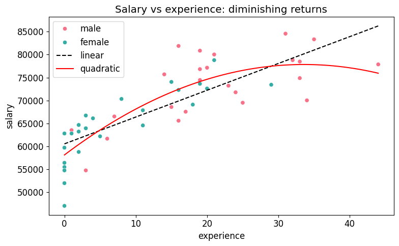

```python
# Visualise linear vs quadratic fit
xx = np.linspace(omega['experience'].min(), omega['experience'].max(), 100)
pred_lin  = model_lin.params['Intercept'] + model_lin.params['experience']*xx
pred_quad = (model_quad.params['Intercept'] + b1*xx + b2*xx**2)

plt.figure(figsize=(8, 5))
sns.scatterplot(data=omega, x='experience', y='salary', hue='gender', palette='husl')
plt.plot(xx, pred_lin,  'k--', label='linear')
plt.plot(xx, pred_quad, 'r-',  label='quadratic')
plt.title('Salary vs experience: diminishing returns')
plt.legend(); plt.tight_layout(); plt.show()
```

> **✅ Answer — yes, the board member is right.** Adding a **squared** experience term fits much better (R² **0.65 → 0.73**), and the `experience²` coefficient is **−17.5, highly significant** ($p < 0.001$). A negative quadratic term means the salary–experience curve is **concave**: each extra year adds *less* than the one before. Concretely, from the quadratic the marginal value of a year is about **£1,069/year around 3 years' experience but only ~£230/year around 27 years** — exactly the pattern described (a 2→4 year jump is worth far more than a 26→28 jump).

> **How to model it.** Two standard options: (1) add a **quadratic term** `experience + I(experience**2)` as above (easy to read, gives the turning point); or (2) model **log(salary)** so coefficients become *approximately percentage* effects (here ≈ **0.9% per year**), which also captures diminishing *absolute* returns and often tames right-skew and heteroskedasticity. Either is a defensible "improved" specification; the quadratic answers the board member's question most directly.

# Summary of the Omega case

| Model | Gender effect | Significant? | R² |
| --- | --- | --- | --- |
| t-test / `salary ~ gender` | +£8,696 | **yes** (p≈0.0002) | 0.26 |
| `salary ~ gender + experience` | +£1,014 | **no** (p≈0.58) | 0.65 |
| `salary ~ gender * experience` | entry-level only, slopes differ | marginal | 0.67 |
| `salary ~ experience + experience²` | — | experience² **yes** | 0.73 |

**Bottom line for the board.** The raw £8,700 gap is real but **almost entirely explained by experience**: men in this sample are far more experienced, experience strongly predicts pay, and the gender term vanishes once it is included. The data therefore give **no statistical evidence of pay discrimination** conditional on experience — while leaving open the prior question of *why* female executives have so much less experience, which no salary regression can answer. As always, this is **observational** data, so every coefficient is an association, not proof of cause.